# IDS 570 - Data Exploration

Tiye Ngachoko

2026-10-15

```r
library(readr)
library(dplyr)
library(tidyr)
library(stringr)
library(tidytext)
library(quanteda)
library(quanteda.textstats)
library(tibble)
library(ggplot2)
```

```r
text_dir <- "C:/Users/titin/OneDrive - Duke University/TAD/Data Exploration/Text Files/"

files <- list.files(text_dir, pattern = "\\.txt$", full.names = TRUE)

texts <- tibble(
  doc_id = str_remove(basename(files), "\\.txt$"),
  text   = vapply(files, read_file, character(1))
)

texts
```

```
## # A tibble: 23 × 2
##    doc_id                     text
##    <chr>                      <chr>
##  1 A06785                     "STrong imagination, nourished by opinion, may ca…
##  2 A06786                     "WHen Almighty God had created man, good and a so…
##  3 A06788                     "A SENTENCE alleged without application to some p…
##  4 A06789                     "NATURAL Mother wit, did teach man, before Arts o…
##  5 A06790                     "APRIL having with his sweet showers moistened th…
##  6 A06791                     "PLato the Philosopher perceiving that equality w…
##  7 A07594__Circle_of_Commerce "THE CIRCLE OF COMMERCE. The Prooeme. HERODOTVS i…
##  8 A07886                     "THe trade of Merchandise, is not only that lauda…
##  9 A32827                     "THE Prodigious increase of the Netherlanders in …
## 10 A32828                     "WHEN fallen Man was driven out of Paradise, the …
## # ℹ 13 more rows
```

```r
texts %>%
  mutate(long_s = str_count(text, "ſ"),
         illegible = str_count(text, "●")) %>%
  select(doc_id, long_s, illegible) %>%
  filter(long_s > 0 | illegible > 0)
```

```
## # A tibble: 14 × 3
##    doc_id                     long_s illegible
##    <chr>                       <int>     <int>
##  1 A06785                          0        47
##  2 A06786                          0       135
##  3 A06789                          0       190
##  4 A06790                          0         4
##  5 A06791                          0        17
##  6 A07594__Circle_of_Commerce   4517         0
##  7 A32827                          0        36
##  8 A32833                          0        93
##  9 A32837                          0         3
## 10 A32839                          0         1
## 11 A50763                          0         6
## 12 A51598                          0         4
## 13 A69858                          0       109
## 14 A93819                          0         6
```

- only circle of commerce has odd s that needs fixing.

```r
texts_clean <- texts %>%
  mutate(
    text = if_else(doc_id == "A07594__Circle_of_Commerce",
                   str_replace_all(text, "ſ", "s"),
                   text),
    text = str_replace_all(text, "●", "") # marker appears in 14 texts
  )

texts_clean %>%
  summarise(long_s = sum(str_count(text, "ſ")),
            illegible = sum(str_count(text, "●")))
```

```
## # A tibble: 1 × 2
##   long_s illegible
##    <int>     <int>
## 1      0         0
```

```r
data("stop_words")

custom_stop <- tibble(
  word = c("vnto","haue","doo","hath","bee","ye","thee","hee","shall","hast",
           "doe","beene","thereof","thus")
)

all_stopwords <- bind_rows(stop_words, custom_stop) %>%
  distinct(word)

words_clean <- texts_clean %>%
  unnest_tokens(word, text) %>%
  filter(!str_detect(word, "[0-9]")) %>%
  anti_join(all_stopwords, by = "word")
```

## 0 - Normalization

The long s appeared only in the Circle of Commerce text (4,517 instances), so I replaced it with “s” in that text alone, so that words like “sonne” would not be interpreted differently in just that one text. I also removed the “●” character from all texts. It is the EEBO transcription marker for illegible characters, and it appeared in 14 of the 23 texts; left in, it breaks words into meaningless fragments. I did not normalize other spelling variation, like u/v and i/j (“giue,” “vpon”). While this may help in some cases, it risks replacing the wrong letters in words that are already spelled correctly. The trade-off is that older-spelling texts may look lexically distinctive in TF-IDF, or cluster together in the correlations, because of spelling rather than content. Lastly, I tokenized the texts, removed the standard tidytext stopword list along with the Early Modern function words from the Week 04 tutorial (“vnto,” “haue,” “hath,” “thereof,” etc.), and dropped tokens containing digits (page numbers, dates and sums of money). The cleaned documents vary greatly in length, from 864 tokens (A32830) to 127,435 (Smith’s Wealth of Nations), which is something that stands out after the past few homework assignments.

```r
dfm_counts <- words_clean %>%
  count(doc_id, word) %>%
  cast_dfm(doc_id, word, n)

dfm_counts
```

```
## Document-feature matrix of: 23 documents, 22,793 features (88.58% sparse) and 0
## docvars.
##         features
## docs     abandon abased abate abateth abating abbaddon abeffectis ability
##   A06785       1      1     1       1       2        1          1       2
##   A06786       6      0     9       2       5        0          0      12
##   A06788       0      0     2       0       2        0          0       4
##   A06789       0      0     3       1       2        0          0       4
##   A06790       1      0     0       0       0        0          0      12
##   A06791       0      0     3       0       1        0          0       1
##         features
## docs     abolished abominable
##   A06785         2          1
##   A06786         5          3
##   A06788         0          0
##   A06789         1          0
##   A06790         1          1
##   A06791         1          0
## [ reached max_ndoc ... 17 more documents, reached max_nfeat ... 22,783 more
## features ]
```

```r
dfm_tfidf_w <- dfm_tfidf(dfm_counts)
dfm_tfidf_w
```

```
## Document-feature matrix of: 23 documents, 22,793 features (88.58% sparse) and 0
## docvars.
##         features
## docs       abandon    abased     abate   abateth   abating abbaddon abeffectis
##   A06785 0.6627578 0.8846066 0.3203352 0.8846066 0.8149707 1.361728   1.361728
##   A06786 3.9765470 0         2.8830164 1.7692132 2.0374266 0          0
##   A06788 0         0         0.6406703 0         0.8149707 0          0
##   A06789 0         0         0.9610055 0.8846066 0.8149707 0          0
##   A06790 0.6627578 0         0         0         0         0          0
##   A06791 0         0         0.9610055 0         0.4074853 0          0
##         features
## docs       ability abolished abominable
##   A06785 0.6406703 1.1671532  0.8846066
##   A06786 3.8440218 2.9178829  2.6538197
##   A06788 1.2813406 0          0
##   A06789 1.2813406 0.5835766  0
##   A06790 3.8440218 0.5835766  0.8846066
##   A06791 0.3203352 0.5835766  0
## [ reached max_ndoc ... 17 more documents, reached max_nfeat ... 22,783 more
## features ]
```

```r
tfidf_mat <- as.matrix(dfm_tfidf_w)

top_tfidf <- lapply(rownames(tfidf_mat), function(doc) {
  top <- sort(tfidf_mat[doc, ], decreasing = TRUE)[1:13]
  tibble(doc_id = doc, term = names(top), tfidf = round(unname(top), 2))
}) %>%
  bind_rows()

top_tfidf_table <- top_tfidf %>%
  group_by(doc_id) %>%
  summarise(top_terms = paste(term, collapse = ", "))

knitr::kable(top_tfidf_table, caption = "Top 13 TF-IDF terms by doc")
```

Top 13 TF-IDF terms by doc

| doc_id | top_terms |
| --- | --- |
| A06785 | moneys, misselden, starlin, exchange, circle, realm, doller, undervaluation, royals, stivers, overbalancing, commodities, centre |
| A06786 | ll, hundreth, ounces, weight, carrats, moneys, ss, factor, assurors, grains, antuerp, silver, ducats |
| A06788 | sols, silver, livers, realm, dearth, commodities, gold, bodine, price, moneys, velvet, shillings, malestroit |
| A06789 | moneys, starlin, monies, exchange, realm, commodities, shillings, doller, enhancing, price, stivers, pence, albeit |
| A06790 | monster, dragon, maketh, moon, tail, ass, sweet, causeth, leaguors, smell, feeding, visions, hell |
| A06791 | realm, moneys, commodities, exchange, fineness, price, shillings, silver, exchangers, albeit, hundredth, bank, weight |
| A07594__Circle_of_Commerce | malynes, kingdome, ballance, forraine, vpon, mony, owne, lesse, forme, himselfe, gaine, vse, sayd |
| A07886 | wares, realm, silkes, indies, indigo, aleppo, rawsilke, ll, yearly, raw, india, kingdom’s, sterling |
| A32827 | plantations, abatement, cent, poor, usury, newfoundland, pag, english, planting, barbadoes, judiciary, planters, shipping |
| A32828 | support, mortgage, disposal, impediments, promotion, purely, commerce, advantages, creditors, thereto, cent, produce, instrumental |
| A32829 | packs, cloth, stuffs, wool, manufactors, cloths, foreigners, thousand, african, em, price, clothiers, chapmen |
| A32830 | taffities, em, muslins, product, scotch, weavers, india, prime, persuade, china, improvement, expended, undeniable |
| A32833 | plantations, abatement, cent, poor, usury, newfoundland, pag, english, planting, barbadoes, planters, laws, thrive |
| A32836 | poor, parish, fathers, propose, hospitals, pious, assembly, question, quest, elected, election, defect, medal |
| A32837 | cent, usurer, usurers, barbadoss, objection, planters, richest, plantations, qualifications, lender’s, territory, improvement, surplusage |
| A32838 | surrat, phirmaund, mogul, bombay, mogul’s, guns, committees, mary, cargoes, english, frigate, hoocombe, husball |
| A32839 | india, tuns, seamen, protestant, arg, bengall, company, charter, regulated, answ, silk, suratt, legitimate |
| A50763 | poor, parish, fathers, goals, propose, hospitals, assembly, design, communication, elected, election, dorchester, whipping |
| A51598 | wares, treasure, genova, foreign, moneys, war, realm, exchange, gain, divers, feats, country’s, wonders |
| A69858 | india, surrat, arg, answ, bantam, tuns, company, charter, bombay, naval, bengall, legitimate, tho |
| A93819 | key, stairs, lion, wharf, edmond, wiseman, thames, defendant, surveyors, wharfige, enrolled, wharves, keys |
| B14801__Free_Trade | kingdome, vpon, forreine, gouernment, maiesties, alphabet, vnder, subiects, christendome, publique, owne, euery, selfe |
| wealth | labor, capital, revenue, expense, system, productive, produce, rent, century, tax, frequently, britain, colonies |

```r
write_csv(top_tfidf, "top_tfidf_terms_DE.csv")
```

## Approach 1 : TF-IDF

Several documents share distinctive vocabulary, which groups the corpus into clear clusters. A32827 and A32833 share 11 of their 13 top terms (plantations, abatement, cent, usury, newfoundland,), which supports they are two related texts, or perhaps even two editions of the same text. A32836 and A50763 are nearly identical too(poor, parish, fathers, hospitals, elected). A32839, A69858 and A32838 share vocabulary related to India/South Asia and trade (india, surrat, bombay, bengall, company, charter), while A06785, A06788, A06789 and A06791 share language about currency and exchange (moneys, exchange, realm, starlin, doller, stivers).

Some other top terms are names: “misselden” in A06785, “malynes” in Circle of Commerce. This shows these texts also refer to specific people relevant to economics and trade, etc. Most distinctive terms are either technical (units/amounts of money like starlin, carrats and grains) or topical (India, plantations, wool and cloth), with A06790 standing out from the rest of the corpus with vocabulary like monster, dragon, moon, visions and hell, which looks more like a fantasy narrative than terms indicative of the study or applications of economics. Still, some distinctiveness is driven by spelling and formatting rather than content. Almost every top term for Circle of Commerce and Free Trade is an outdated spelling (vpon, owne, mony, forraine, sayd, gouernment, euery, selfe), which reflects the trade-off of not normalizing spelling in Step 0: these texts may share ideas with the rest of the corpus but look distinctive because of how they are spelled.

```r
dfm_trimmed <- dfm_trim(dfm_counts, min_termfreq = 5)

dfm_trimmed
```

```
## Document-feature matrix of: 23 documents, 7,158 features (75.90% sparse) and 0
## docvars.
##         features
## docs     abandon abate abating ability abolished abominable abound abounding
##   A06785       1     1       2       2         2          1      1         1
##   A06786       6     9       5      12         5          3      7         0
##   A06788       0     2       2       4         0          0      3         1
##   A06789       0     3       2       4         1          0      2         0
##   A06790       1     0       0      12         1          1      1         0
##   A06791       0     3       1       1         1          0      4         0
##         features
## docs     abovesaid abroad
##   A06785         2      2
##   A06786        15      9
##   A06788         1      0
##   A06789         1      2
##   A06790         0      0
##   A06791         0      1
## [ reached max_ndoc ... 17 more documents, reached max_nfeat ... 7,148 more
## features ]
```

```r
# words removed by trimming
removed <- setdiff(featnames(dfm_counts), featnames(dfm_trimmed))
length(removed)
```

```
## [1] 15635
```

```r
# a random sample of those removed words
set.seed(570)
sample(removed, 40)
```

```
##  [1] "combustible"   "things.colleg" "efficeint"     "conchas"
##  [5] "habitable"     "endured"       "humano"        "whites"
##  [9] "olive"         "inequitable"   "multiplicitie" "cherrished"
## [13] "substituted"   "gammuth"       "intrinsical"   "istria"
## [17] "egyptions"     "umpire"        "alquiers"      "favoring"
## [21] "sicke"         "mentz"         "banditti"      "multiplyed"
## [25] "intercept"     "woodashes"     "construct"     "tasted"
## [29] "lochs"         "predominancy"  "scores"        "facilius"
## [33] "coppenghen"    "surnamed"      "subsidiary"    "apple"
## [37] "scantily"      "untrodden"     "campeche"      "overbeareth"
```

```r
# of the words KEPT, how many appear in only one document?
kept_docfreq <- docfreq(dfm_trimmed)
sum(kept_docfreq == 1)
```

```
## [1] 867
```

```r
sum(kept_docfreq == 1) / nfeat(dfm_trimmed)
```

```
## [1] 0.1211232
```

```r
lost <- tibble(
  doc_id = docnames(dfm_counts),
  tokens_before = as.numeric(ntoken(dfm_counts)),
  tokens_after  = as.numeric(ntoken(dfm_trimmed))
) %>%
  mutate(pct_removed = round(100 * (1 - tokens_after / tokens_before), 1)) %>%
  arrange(desc(pct_removed))

lost # which documents lost the most when rare words were removed
```

```
## # A tibble: 23 × 4
##    doc_id                     tokens_before tokens_after pct_removed
##    <chr>                              <dbl>        <dbl>       <dbl>
##  1 B14801__Free_Trade                  7806         6017        22.9
##  2 A07594__Circle_of_Commerce         12593        10003        20.6
##  3 A06790                              4215         3402        19.3
##  4 A93819                               972          839        13.7
##  5 A32838                              1063          930        12.5
##  6 A06785                             12756        11462        10.1
##  7 A06786                             81360        73425         9.8
##  8 A32828                              2003         1813         9.5
##  9 A06789                              8499         7795         8.3
## 10 A32829                              1489         1372         7.9
## # ℹ 13 more rows
```

```r
# pairwise Pearson correlations between all documents
sim_r <- textstat_simil(dfm_trimmed, margin = "documents", method = "correlation")

# Convert similarity object to a matrix
r_mat <- as.matrix(sim_r)

# Take a quick look
dim(r_mat)
```

```
## [1] 23 23
```

```r
r_mat[1:5, 1:5]
```

```
##           A06785    A06786    A06788    A06789    A06790
## A06785 1.0000000 0.6075157 0.5583472 0.8764435 0.2005168
## A06786 0.6075157 1.0000000 0.6902137 0.6723767 0.3093758
## A06788 0.5583472 0.6902137 1.0000000 0.7025278 0.3397027
## A06789 0.8764435 0.6723767 0.7025278 1.0000000 0.2609244
## A06790 0.2005168 0.3093758 0.3397027 0.2609244 1.0000000
```

```r
# rounding correlation for readability (see explanation below)
r_mat <- round(r_mat, 3)
```

```r
pairs <- as.data.frame(r_mat) %>%
  rownames_to_column("doc_i") %>%
  pivot_longer(-doc_i, names_to = "doc_j", values_to = "r") %>%
  filter(doc_i < doc_j)

pairs %>% arrange(desc(r)) %>% head(5)   # most similar
```

```
## # A tibble: 5 × 3
##   doc_i  doc_j      r
##   <chr>  <chr>  <dbl>
## 1 A32827 A32833 1
## 2 A32836 A50763 0.979
## 3 A32839 A69858 0.942
## 4 A06785 A06789 0.876
## 5 A06789 A06791 0.857
```

```r
pairs %>% arrange(r) %>% head(5)         # least similar
```

```
## # A tibble: 5 × 3
##   doc_i  doc_j      r
##   <chr>  <chr>  <dbl>
## 1 A32830 A93819 0.041
## 2 A06791 A93819 0.045
## 3 A07886 A93819 0.055
## 4 A32829 A93819 0.057
## 5 A06790 A93819 0.059
```

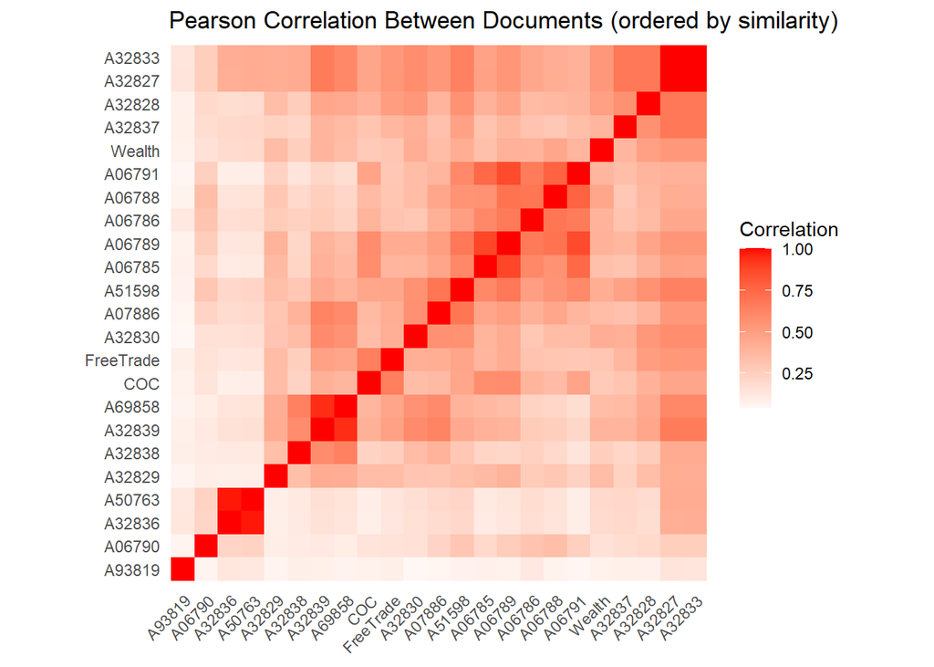

```r
short_names <- c("A07594__Circle_of_Commerce" = "COC",
                 "B14801__Free_Trade"         = "FreeTrade",
                 "wealth"                     = "Wealth")

r_short <- r_mat
rownames(r_short) <- recode(rownames(r_short), !!!short_names)
colnames(r_short) <- recode(colnames(r_short), !!!short_names)

doc_order <- rownames(r_short)[hclust(as.dist(1 - r_short))$order]

# Long format for ggplot
heat_df <- as.data.frame(r_short) %>%
  rownames_to_column("doc_i") %>% # First document in pair
  pivot_longer(-doc_i, names_to = "doc_j", values_to = "r") %>% # Second document + correlation
  mutate(doc_i = factor(doc_i, levels = doc_order),
         doc_j = factor(doc_j, levels = doc_order))

# create the heatmap
ggplot(heat_df, aes(x = doc_j, y = doc_i, fill = r)) +
  geom_tile() + # Create colored tiles
  coord_fixed() + # Keep tiles square
  scale_fill_gradient2(
    low = "blue",
    mid = "white",
    high = "red",
    midpoint = 0 # Center color scale at 0
  ) +
  labs(title = "Pearson Correlation Between Documents (ordered by similarity)",
       x = NULL,
       y = NULL,
       fill = "Correlation") +
  theme_minimal() +
  theme(axis.text.x = element_text(angle = 45, hjust = 1),
        panel.grid = element_blank())
```

```r
ggsave("correlation_heatmap_DE.png", width = 9, height = 8)
```

## Approach 2: Pearson correlation

Before computing correlations, I trimmed words that appeared fewer than 5 times in the corpus, which removed 15,635 of 22,793 unique words, about 69%, and reduced sparsity from 88.58% to 75.90%. A random sample of 40 removed words was roughly split: about half were modern English words that are rare in this corpus (“combustible,” “olive,” “umpire”), while the rest were alternate or more archaic spellings (“multiplicitie,” “sicke,” “overbeareth”), non-English words like “humano”, place names like “campeche” and an error, “things.colleg”. After trimming, 88% of the remaining words appeared in at least two documents. Trimming did not affect all documents equally: the median document lost ~7% of its words, but Free Trade (22.9%), Circle of Commerce (20.6%) and A06790 (19.3%) lost about three times as much.

All correlations were positive, ranging from 0.041 to ~1.000, so every text shares at least some vocabulary with every other. The two most similar pairs were A32827 and A32833 (r = 1.000) and A32836 and A50763 (r = 0.979), the same pairs TF-IDF showed sharing nearly identical distinctive terms. A correlation of 1.000 means their word use is essentially identical, which further supports they are two versions of the same text. The two least similar pairs were A32830 and A93819 (r = 0.041) and A06791 and A93819 (r = 0.045). All five of the lowest correlations involved A93819, placing as an outlier within this specific corpus.Ordered by similarity, the heatmap shows blocks that mostly match the TF-IDF results: money and exchange (A06785, A06786, A06788, A06789), India and trade (A32838, A32839, A69858). Circle of Commerce and Free Trade sit together, likely in part because of their shared older spelling.

Some questions raised: - Are Circle of Commerce and Free Trade similar because of shared ideas, or just shared words spellings? Normalizing their spellings and re-running the correlations would help clarify this. - Since A32827 and A32833 are almost duplicates, do they skew our corpus significantly, especially when calculated TF-IDF? - Does A93819 belong in this corpus? It was the most outliing text in terms of least correlated documents. Is it connected to the others beyond what just vocabulary can show?

```r
library(udpipe)
library(purrr)
```

```r
texts_df <- texts_clean %>%
  filter(doc_id %in% c("A32836", "A50763", "A32830", "A93819")) %>%
  rename(document = doc_id) %>%
  mutate(pair = if_else(document %in% c("A32836", "A50763"),
                        "Most similar (r = 0.979)",
                        "Least similar (r = 0.041)"))

texts_df %>%
  mutate(n_words = str_count(text, "\\S+")) %>%
  select(document, pair, n_words)
```

```
## # A tibble: 4 × 3
##   document pair                      n_words
##   <chr>    <chr>                       <int>
## 1 A32830   Least similar (r = 0.041)    2927
## 2 A32836   Most similar (r = 0.979)     4782
## 3 A50763   Most similar (r = 0.979)     5232
## 4 A93819   Least similar (r = 0.041)    2567
```

```r
model_info <- udpipe_download_model(language = "english-ewt")
ud_model <- udpipe_load_model(model_info$file_model)

model_info$file_model
```

```
## [1] "C:/Users/titin/OneDrive - Duke University/TAD/Data Exploration/english-ewt-ud-2.5-191206.udpipe"
```

```r
anno_df <- texts_df %>%
  mutate(
    # Parse each text with the UD parser; set doc_id to our document name
    anno = map2(text, document, ~ udpipe_annotate(ud_model, x = .x, doc_id = .y) %>%
      as.data.frame())
  ) %>%
  # Keep only parsed annotations, then unnest into rows
  select(pair, anno) %>%
  unnest(anno) %>%
  # Use the UD doc_id as our document label (and drop any duplicates cleanly)
  rename(document = doc_id) %>%
  # Select columns for syntactic analysis
  select(
    document,
    pair,
    paragraph_id,
    sentence_id,
    token_id,
    token,
    lemma,
    upos,          # part of speech
    feats,         # grammatical features (e.g., verb form)
    head_token_id, # head of dependency relation
    dep_rel        # dependency relation type
  )

anno_df %>%
  group_by(document) %>%
  summarise(sentences = n_distinct(paste(paragraph_id, sentence_id)),
            tokens = n())
```

```
## # A tibble: 4 × 3
##   document sentences tokens
##   <chr>        <int>  <int>
## 1 A32830          71   3383
## 2 A32836         116   5461
## 3 A50763         125   5967
## 4 A93819          60   3000
```

```r
syntax_df <- anno_df %>%
  mutate(
    is_word = upos != "PUNCT", #<--is it a word (and not punctuation?)

    # Is this an independent clause? finite verbs are proxy for indipendent clauses
    is_clause = (upos %in% c("VERB", "AUX")) &
                str_detect(coalesce(feats, ""), "VerbForm=Fin"),

    # Dependent clause?
    is_dep_clause = dep_rel %in% c(
      "advcl", #adverbial clause
      "ccomp", # clausal complement
      "xcomp", #open clausal complement
      "acl", #adnomial clause
      "acl:relcl" #relative clause
    ),

    # Is this coordination? That is, does it use "and" "or" etc.?
    is_coord = dep_rel %in% c("conj", "cc"),

    # Nominal complexity: these relations make noun phrases more complex
    is_complex_nominal = dep_rel %in% c(
      "amod", # adjective modifier ("big cup")
      "nmod", #nominal modifier ("cup of tea")
      "compound", # compound ("lemon tea")
      "appos" #apposition ("tea, my favorite!")
    )
  )

syntax_df %>%
  group_by(document) %>%
  summarise(words = sum(is_word),
            clauses = sum(is_clause),
            dep_clauses = sum(is_dep_clause),
            coord = sum(is_coord),
            complex_nominals = sum(is_complex_nominal))
```

```
## # A tibble: 4 × 6
##   document words clauses dep_clauses coord complex_nominals
##   <chr>    <int>   <int>       <int> <int>            <int>
## 1 A32830    2952     261         232   261              377
## 2 A32836    4811     390         365   571              638
## 3 A50763    5260     409         383   651              725
## 4 A93819    2617     160         135   372              452
```

```r
sentence_df <- syntax_df %>%
  filter(is_word) %>%           #count words (not punctuation)
  group_by(document, pair, paragraph_id, sentence_id) %>%   #group by document and sentence
  summarise(
    words          = n(),   #number of words per sentence
    clauses        = sum(is_clause), # number of clauses per sentence
    dep_clauses    = sum(is_dep_clause), #number of dependent clauses per sentence
    .groups = "drop"
  )

doc_totals <- syntax_df %>%
  group_by(document) %>%
  summarise(coord = sum(is_coord),
            complex_nominals = sum(is_complex_nominal),
            .groups = "drop")

# Combine all measures
all_measures <- sentence_df %>%
  group_by(document, pair) %>%
  summarise(sentences = n(),
            MLS = mean(words), # Average words per sentence
            clauses = sum(clauses),
            dep_clauses = sum(dep_clauses),
            .groups = "drop") %>%
  left_join(doc_totals, by = "document") %>%
  mutate(C_per_S     = clauses / sentences, #Calculate clauses per sentence
         DC_per_C    = dep_clauses / pmax(clauses, 1), #avoid division by 0 (shouldn't happen, but if no clauses were detected in the sentence, we still want it to run)
         DC_per_S    = dep_clauses / sentences,
         Coord_per_C = coord / pmax(clauses, 1),
         Coord_per_S = coord / sentences,
         CN_per_C    = complex_nominals / pmax(clauses, 1),
         CN_per_S    = complex_nominals / sentences) %>%
  select(pair, document, MLS, C_per_S, DC_per_C, DC_per_S,
         Coord_per_C, Coord_per_S, CN_per_C, CN_per_S) %>%
  arrange(pair, document)

all_measures %>%
  knitr::kable(
    digits = 2,
    col.names = c("Pair", "Document", "MLS", "C/S", "DC/C", "DC/S",
                  "Coord/C", "Coord/S", "CN/C", "CN/S")
  )
```

| Pair | Document | MLS | C/S | DC/C | DC/S | Coord/C | Coord/S | CN/C | CN/S |
| --- | --- | --- | --- | --- | --- | --- | --- | --- | --- |
| Least similar (r = 0.041) | A32830 | 41.58 | 3.68 | 0.89 | 3.27 | 1.00 | 3.68 | 1.44 | 5.31 |
| Least similar (r = 0.041) | A93819 | 43.62 | 2.67 | 0.84 | 2.25 | 2.33 | 6.20 | 2.83 | 7.53 |
| Most similar (r = 0.979) | A32836 | 41.47 | 3.36 | 0.94 | 3.15 | 1.46 | 4.92 | 1.64 | 5.50 |
| Most similar (r = 0.979) | A50763 | 42.08 | 3.27 | 0.94 | 3.06 | 1.59 | 5.21 | 1.77 | 5.80 |

```r
write_csv(all_measures, "syntax_measures_DE.csv")
```

```r
sentence_examples <- syntax_df %>%
  group_by(document, paragraph_id, sentence_id) %>%
  summarise(text = paste(token, collapse = " "),
            words = sum(is_word),
            clauses = sum(is_clause),
            coord = sum(is_coord),
            nominals = sum(is_complex_nominal),
            .groups = "drop") %>%
  filter(words >= 20, words <= 50, clauses >= 1) %>%
  mutate(coord_per_clause = coord / clauses)

# A93819: noun and coordination-heavy sentences
sentence_examples %>%
  filter(document == "A93819") %>%
  slice_max(coord_per_clause, n = 3, with_ties = FALSE) %>%
  select(words, clauses, coord, nominals, text)
```

```
## # A tibble: 3 × 5
##   words clauses coord nominals text
##   <int>   <int> <int>    <int> <chr>
## 1    48       1    15        9 Nicholas St. Leger and Dame Katherine his Wife ,…
## 2    35       1    13        3 William Bury , and John Bury , and Johanna Lowen…
## 3    35       1     9        7 Thomas Reynolds and his Wife by Deed indented an…
```

```r
# A32830: clause-heavy sentences
sentence_examples %>%
  filter(document == "A32830") %>%
  slice_max(clauses, n = 3, with_ties = FALSE) %>%
  select(words, clauses, coord, nominals, text)
```

```
## # A tibble: 3 × 5
##   words clauses coord nominals text
##   <int>   <int> <int>    <int> <chr>
## 1    42       8     2        5 Methinks the late extraordinary endeavours of ou…
## 2    48       7     2        2 Suppose then the Merchant is forced to sell this…
## 3    43       6     3        4 In Fine ; so every way Fitted to the General Int…
```

```r
sentence_examples %>%
  filter(document == "A93819") %>%
  slice_max(coord_per_clause, n = 3, with_ties = FALSE) %>%
  pull(text)
```

```
## [1] "Nicholas St. Leger and Dame Katherine his Wife , and Thomas Kemp and his Wife , by Deed indented sell their parts of the said Premises to Edmond Wiseman and his Heirs , and a Fine there upon Levied , Edmond Wiseman Querent , and Nicholas St. Leger and Katherine his Wife Deforceants ."
## [2] "William Bury , and John Bury , and Johanna Lowen , and their Wives , by Deed indented and enrolled in the Hustings in London , bargain and sell their parts of the Premises to Edmomd Wiseman and his Heirs ."
## [3] "Thomas Reynolds and his Wife by Deed indented and enrolled in Chancery , bargain and sell his part of the said Premises to Edmond Wiseman and his Heirs , another Deed of Covenants of the same date ."
```

```r
sentence_examples %>%
  filter(document == "A32830") %>%
  slice_max(clauses, n = 3, with_ties = FALSE) %>%
  pull(text)
```

```
## [1] "Methinks the late extraordinary endeavours of our Scotch Friends , who are generally esteemed wise enough for themselves , to establish a Commerce thither , should make our Opposers of this Trade consider , whether it is a thing so damageable as they say it is ."
## [2] "Suppose then the Merchant is forced to sell this Corn for only so much above the prime Cost , as he has expended in Charges , it may be 2000 l. in this Case , though the Merchant has gained nothing , yet it is plain the Kingdom has increased 2000 l ."
## [3] "In Fine ; so every way Fitted to the General Interest and Profit of the NATION , That I am persuaded , that were it Encouraged , as it might be , it would Equal , if not Excel , any other Foreign Commerce that is used by this KINGDOM ."
```

## Approach 3: Syntactic complexity

I compared two pairs chosen from Approach 2: the most similar (A32836 and A50763, r = 0.979) and the least similar (A32830 and A93819, r = 0.041), to see whether lexical similarity also shows up in how the texts are written. All four were parsed with udpipe’s English-EWT model. Since it’s trained on modern English, some parsing errors are likely to occur with the older texts.

Sentence length was almost the same across all four texts (41.58–43.62 words). The most similar pair was also nearly identical syntactically (C/S 3.36 vs 3.27, DC/C 0.94 for both), which again supports them being versions of the same text. The least similar pair differed in how sentences are built intead of their length; A93819 had fewer clauses per sentence (2.67 vs 3.68) but more than twice the coordination per clause (2.33 vs 1.00) and nearly twice the complex nominals per clause (2.83 vs 1.44). Subordination was similar across all four texts (DC/C 0.84–0.94), partly because the dependent-clause count includes non-finite clauses, so it’s better read as a comparison between texts than as an exact proportion.

The example sentences show this difference. A93819: “William Bury, and John Bury, and Johanna Lowen, and their Wives, by Deed indented and enrolled in the Hustings in London, bargain and sell their parts of the Premises to Edmomd Wiseman and his Heirs.”. “bargain and sell” is between a chain of names. A32830: “Suppose then the Merchant is forced to sell this Corn for only so much above the prime Cost, as he has expended in Charges, it may be 2000 l. in this Case, though the Merchant has gained nothing, yet it is plain the Kingdom has increased 2000 l.” is clause heavy.

These results align with the lexical findings: the pair that shared vocabulary also shared syntax, and the pair that shared almost none differed in structure. They also add context. A93819’s list-like style and its vocabulary suggest it being a record rather than a narritive or argument, which may help explain why it’s the outlier, while A32830 adds reasoning and examples.

### Synthesis

Central idea: Texts that share vocabulary in this corpus also tend to share sentence structure, so lexical and syntactic similarity, at least in this instance, are aligned

Evidence from each approach:

TF-IDF: A32836 and A50763 shared nearly identical distinctive words, while A93819’s words were unlike the rest of the corpus. Correlation: A32836 and A50763 were the second most similar pair (r = 0.979), and A93819 was in all five least similar pairs. Syntax: A32836 and A50763 had nearly identical profiles, while A93819 and A32830 differed in structure: A93819 was list-like and noun-heavy, and A32830 was clause-heavy.

Limitations: TF-IDF and correlation were both affected by spelling variation and by near-duplicate texts, and the parser is trained on modern English. I also only compared four texts syntactically, so this pattern would need to be tested on more of the corpus to make a greater argument.